# Getting started with Enroll-HD data

A tutorial for statisticians, in R and the tidyverse  
Built only from publicly available Enroll-HD documentation. No real participant data are used or shown; every table and figure is illustrative.

Abhishek

2026-09-25

## Disclaimer

**Public information only, no real data**

- This deck is built **only from publicly available material**: the Enroll-HD documentation set published for researchers (protocol, data dictionary, annotated case report forms, data-collection guidelines, dataset overview and interpretation guides), the *Analyzing Data* articles at enroll-hd.org, and the public HDClarity documents (protocol, lab manual, PDS4 dictionary, dataset-structure guide, PDS overviews).
- **No Enroll-HD or HDClarity participant data are used, shown or summarised.** Every table printed by the code is a small **illustrative** dataset generated in `R/make_toy_pds.R`; the simulated releases described in section 11 are synthetic too; every histogram or curve is either synthetic or an approximate redrawing of a figure already published on enroll-hd.org, and is labelled as such.
- Numbers quoted in the text (cohort size, distributions, retention, cut points) are taken from those public documents and articles and are cited for orientation, not for analysis.
- Nothing here replaces the official documentation or the data use agreement that governs access to a periodic dataset.

## What this deck is for

- You are a statistician who has just been given (or is about to request) an Enroll-HD periodic dataset.
- In the next hour you will learn **what the disease and the study are**, **how the files fit together**, **the conventions that bite**, and **how to start an analysis in tidy R**.
- Every code chunk runs on tiny illustrative tables built in `R/make_toy_pds.R`. No participant data are used or shown.
- Sources: the Enroll-HD documentation set and the *Analyzing Data* articles at enroll-hd.org. Links are on the last slide.

## Agenda

1. Huntington’s disease in five minutes
2. The Enroll-HD platform and its periodic datasets
3. Anatomy of a PDS: files, keys, visits
4. Loading and merging with the tidyverse
5. De-identification conventions and missing values
6. Disease definitions and derived scores
7. Special characteristics of HD data
8. Age, CAG and time in models
9. Coded therapies and comorbidities
10. Data quality and a pre-analysis checklist
11. HDClarity, and simulated releases for testing your code

# 1. Huntington’s disease in five minutes

## The gene and the repeat

- Autosomal dominant, caused by a CAG repeat expansion in *HTT*.
- The **larger allele** (`caghigh` in the data) is what matters:

| CAG repeats | Meaning |
| --- | --- |
| 10 to 26 | normal |
| 27 to 35 | intermediate allele |
| 36 to 39 | reduced penetrance |
| 40 and above | full penetrance |
| above 60 | usually juvenile onset |

- Modal expanded CAG in Enroll-HD is **42**; most carriers sit between 40 and 44. Modal non-expanded allele is **17**.
- Longer repeats mean earlier onset, but with wide variation at any given length.
- Every participant is genotyped at a central research lab. The result is never returned to participants or sites; it is for research only.
- “HDGEC” = HD gene expansion carrier (36+). Controls are family members without the expansion.

## One disease, several clocks

Onset is not one event. Different domains start at different times, and the data hold several onset variables.

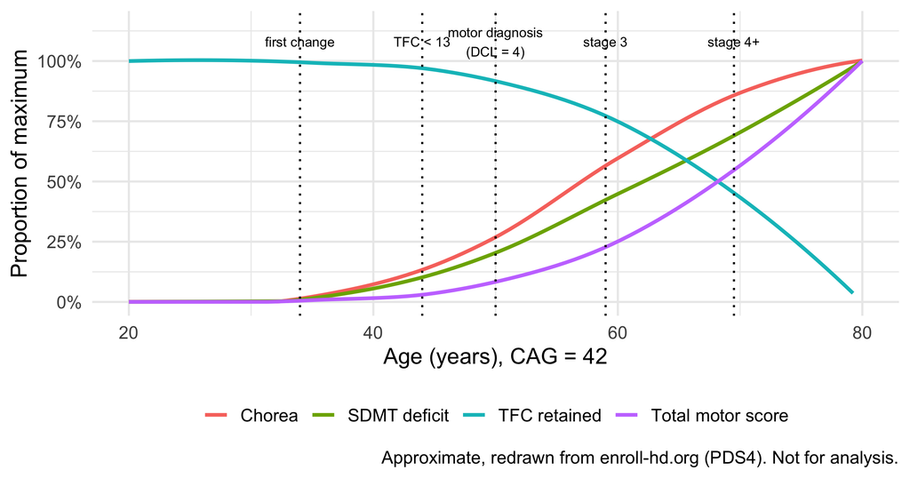

## Two definitions of “manifest”

**Motor diagnosis** (the literature’s “manifest”)

- Diagnostic Confidence Level `diagconf` = 4: motor signs are unequivocal signs of HD (99% confidence).
- Derived from the UHDRS motor exam at each visit.
- The **first visit** at which `diagconf` becomes 4 is the motor-onset date.

**Participant category** `hdcat`

| code | category |
| --- | --- |
| 2 | premanifest / premotor-manifest |
| 3 | manifest / motor-manifest |
| 4 | genotype negative |
| 5 | family control |

- Clinician judgement on **any** domain (motor, cognitive, behavioural). Some manifest participants have DCL below 4.
- Codes 1 (unknown) and 6 (community control) never appear in a PDS.

## CAP: putting age and CAG on one scale

The CAG-Age Product summarises cumulative exposure to mutant huntingtin, like pack-years for smoking.

$$\text{CAP} = \text{age} \times \frac{\text{CAG} - 30}{6.49}$$

- Standardised so that **CAP = 100 at the expected age of motor diagnosis** (Warner et al. 2020). This is the `capscore` column in the PDS, computed at every visit for CAG 36 and above.
- Older variants exist: Zhang 2011 uses age × (CAG − 33.66) with stages early < 290, mid 290 to 367, late > 367. Say which one you use.
- CAP is undefined for people without the expansion. Do not compute it for controls.
- Enroll-HD quartile cut points for CAG 40+ (PDS4): 88 and 119, giving groups below 88, 88 to 119, above 119.

```r
cap_score <- function(age, cag) {
  # Warner et al. (2020) standardisation; NA for non-expanded alleles
  if_else(cag >= 36, age * (cag - 30) / 6.49, NA_real_)
}
cap_score(age = c(45, 45, 60), cag = c(42, 17, 40))
```

```
[1] 83.20493       NA 92.44992
```

# 2. The Enroll-HD platform

## What is measured at a visit

**Core (every visit)**

- Demographics, HD clinical characteristics, medications, comorbidities, therapies
- UHDRS motor and diagnostic confidence
- UHDRS Total Functional Capacity, Functional Assessment, Independence Scale
- Cognitive: Symbol Digit Modalities, Stroop word / colour / interference, category fluency
- Problem Behaviours Assessment short form (PBA-s)
- Biosamples (CAG at baseline)

**Extended and optional**

- Letter fluency, Trail Making A and B, MMSE
- HADS-SIS (anxiety, depression, irritability)
- Columbia Suicide Severity Rating Scale
- SF-12 health survey, WPAI work productivity
- Physiotherapy: timed up-and-go, chair stand
- Caregiver quality of life, service receipt inventory
- Reportable events: suicide attempt, suicide, mental-health hospitalisation, death

## Periodic datasets (PDS)

- Time-stamped cuts of the whole database, released every one to two years. PDS7 (2025) holds about **30,500 participants** and **130,000 visits**.
- Everyone in a PDS has a monitored baseline; most have follow-ups. Enrolment more than 15 months before the cut requires a further reviewed contact, so single-visit participants are mostly recent enrolments.
- Access: verify your institution, sign the data use agreement, post a short project description. Access is free and takes days, not months.
- **Specified datasets (SPS)** can be requested for variables suppressed from the PDS (site, dates, item-level questionnaires, family history), after scientific review.
- Public tier versus “available upon SRC approval” tier: the data dictionary tells you which.

## The documentation you should read first

| Document | Why it matters |
| --- | --- |
| Data dictionary (xlsx) | Every variable: file, form, type, code list, transformation, availability tier. The single source of truth |
| Explore Dataset Structure | Entity-relationship diagram, keys, visit ordering |
| Understand and Interpret Data | HD category rules, missing codes, date handling, score calculations, HD-ISS |
| Coding Systems | Drug, indication and comorbidity code formats |
| PDS overview | Sample sizes, distributions, completeness by form |
| Study protocol, annotated CRFs, data-collection guidelines | What was asked, in what order, with what skip logic |
| Unusual findings | Verified-correct oddities you will otherwise chase as bugs |

# 3. Anatomy of a PDS

## Eleven files, three grains

| File | Grain | Key | Content |
| --- | --- | --- | --- |
| profile | participant | subjid | demographics, HD clinical characteristics, CAG, mortality |
| pharmacotx | participant, repeating | subjid + row | medications with start/stop days, codes, ATC |
| nutsuppl | participant, repeating | subjid + row | nutritional supplements |
| nonpharmacotx | participant, repeating | subjid + row | physiotherapy, speech therapy, counselling ... |
| comorbid | participant, repeating | subjid + row | conditions (ICD-10) and procedures |
| participation | participant x study | subjid + studyid | status, category at entry and latest, visit list, end of study |
| assessment | visit | subjid + studyid + seq | 1/blank flag per form completed at the visit |
| event | reportable event | subjid + studyid + seq | suicide attempt, suicide, hospitalisation, death |
| enroll | Enroll-HD visit | subjid + studyid + seq | all Enroll-HD visit forms and scores |
| registry | REGISTRY visit | subjid + studyid + seq | REGISTRY 2 and 3 visit forms |
| adhoc | retrospective visit | subjid + studyid + seq | UHDRS, cognitive and MMSE collected before REGISTRY |

## Studies and visits inside one PDS

`studyid`

| code | study | when |
| --- | --- | --- |
| ENR | Enroll-HD | mandatory, `visdy` from 0 |
| R3 | REGISTRY v3 | before ENR, negative `visdy` |
| R2 | REGISTRY v2 | before R3 |
| RET | Ad hoc / retrospective | before everything |

`visit`

- Baseline, Follow Up, Unscheduled, Phone Contact, Retro Visit
- `seq` = 1 at baseline, then chronological, **including** unscheduled visits and phone contacts
- Phone contacts carry only the Missed Visit form; unscheduled visits carry the core battery but not MMSE, SF-12, HADS or WPAI
- `visdy` = days since the **Enroll-HD** baseline, for every study

## The keys in one picture

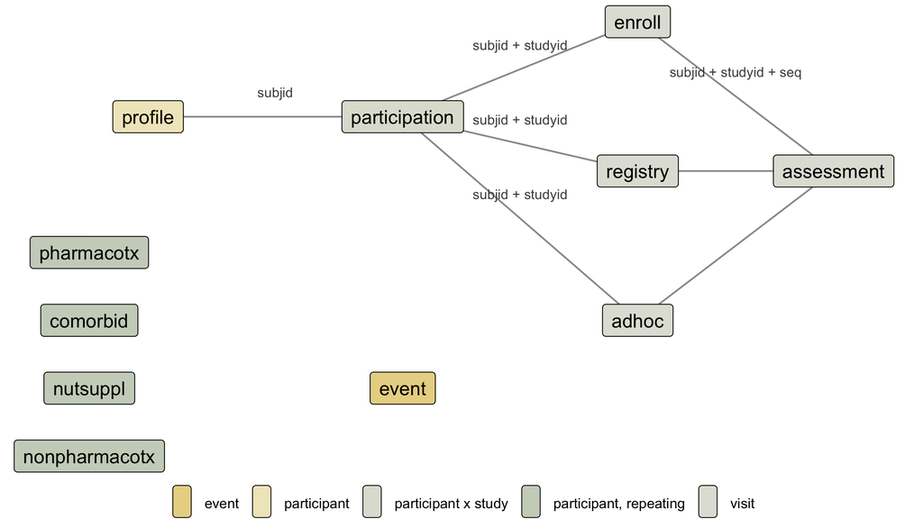

# 4. Loading and merging

## Read everything as text first

The PDS ships as delimited text, one file per table, blank for missing. Aggregated cells such as `">70"` and `"<18"` sit inside otherwise numeric columns, so **read as character and convert deliberately**.

```r
pds_dir <- here::here("data", "pds7")

read_pds <- function(name) {
  read_delim(
    file.path(pds_dir, paste0(name, ".csv")),
    delim = ",",                 # check: some releases are tab-delimited
    col_types = cols(.default = col_character()),
    na = c("", "NA"),
    show_col_types = FALSE
  )
}

pds <- c("profile", "participation", "enroll", "registry",
         "adhoc", "assessment", "event", "pharmacotx",
         "nutsuppl", "nonpharmacotx", "comorbid") |>
  set_names() |>
  map(read_pds)
```

For the rest of this deck `pds` is the toy list from `make_toy_pds()`, already typed.

## Participant tables and visit tables

```r
pds$profile |> select(subjid, sex, caghigh, caglow, hddiagn)
```

```
# A tibble: 8 × 5
  subjid     sex   caghigh caglow hddiagn
  <chr>      <chr> <chr>   <chr>    <dbl>
1 R000000001 f     42      17          48
2 R000000002 f     44      19          41
3 R000000003 f     17      15          NA
4 R000000004 m     40      18          NA
5 R000000005 f     47      20          35
6 R000000006 f     19      16          NA
7 R000000007 f     39      17          NA
8 R000000008 m     >70     >28         30
```

```r
pds$enroll |> select(subjid, seq, visit, visdy, age, hdcat, motscore, diagconf) |> head(6)
```

```
# A tibble: 6 × 8
  subjid       seq visit     visdy age   hdcat motscore diagconf
  <chr>      <int> <chr>     <int> <chr> <dbl>    <dbl>    <dbl>
1 R000000001     1 Baseline      0 52        3       26        4
2 R000000001     2 Follow Up   363 53        3       29        4
3 R000000001     3 Follow Up   730 54        3       36        4
4 R000000002     1 Baseline      0 45        3       27        4
5 R000000002     2 Follow Up   369 46        3       27        4
6 R000000003     1 Baseline      0 38        5        0        0
```

## Merging participant data onto visits

The join keys are `subjid` for participant tables and `subjid + studyid + seq` (or `subjid + visdy`) for visit tables. Say which grain the result has.

```r
carriers <- pds$profile |>
  mutate(cag = parse_number(caghigh)) |>      # ">70" becomes 70; see next section
  filter(cag >= 36)

visits <- pds$enroll |>
  inner_join(carriers |> select(subjid, sex, cag), by = "subjid") |>
  left_join(pds$participation |> select(subjid, studyid, hdcat_0, age_0),
            by = c("subjid", "studyid")) |>
  mutate(years_in_study = visdy / 365.25)

visits |> select(subjid, seq, years_in_study, sex, cag, hdcat_0, motscore) |> head(5)
```

```
# A tibble: 5 × 7
  subjid       seq years_in_study sex     cag hdcat_0 motscore
  <chr>      <int>          <dbl> <chr> <dbl>   <dbl>    <dbl>
1 R000000001     1          0     f        42       3       26
2 R000000001     2          0.994 f        42       3       29
3 R000000001     3          2.00  f        42       3       36
4 R000000002     1          0     f        44       3       27
5 R000000002     2          1.01  f        44       3       27
```

## The “last visit” and “first visit” patterns

```r
last_visit <- pds$enroll |>
  group_by(subjid, studyid) |>
  slice_max(seq, n = 1, with_ties = FALSE) |>
  ungroup()

baseline <- pds$enroll |>
  filter(visit == "Baseline")          # equivalently seq == 1 and visdy == 0

bind_rows(baseline = baseline, latest = last_visit, .id = "which") |>
  count(which, hdcat)
```

```
# A tibble: 8 × 3
  which    hdcat     n
  <chr>    <dbl> <int>
1 baseline     2     2
2 baseline     3     4
3 baseline     4     1
4 baseline     5     1
5 latest       2     1
6 latest       3     5
7 latest       4     1
8 latest       5     1
```

Prefer `slice_max(seq)` over `filter(visdy == max(visdy))`: it is explicit about ties and reads as the intent.

## participation is wide; make it long

`participation` lists visits as `visit1 ... visit21` and `vis1dy ... vis21dy`. Reshape before you count.

```r
visit_list <- pds$participation |>
  select(subjid, studyid, starts_with("visit"), matches("^vis\\d+dy$")) |>
  pivot_longer(
    cols = -c(subjid, studyid),
    names_to = c(".value", "index"),
    names_pattern = "(visit|vis)(\\d+)(?:dy)?"
  ) |>
  rename(visit_type = visit, visit_day = vis) |>
  filter(!is.na(visit_type)) |>
  mutate(index = as.integer(index), visit_day = as.integer(visit_day))
```

Visit types there are abbreviated: BL, FUP, PC (phone contact), U (unscheduled), R (ad hoc), E (premature end).

# 5. De-identification conventions

## No dates, only days and ages

- Every date became a **day offset from the Enroll-HD baseline**: `visdy`, `cmstdy`, `cmendy`, `mhstdy`, `evtdy`, `rfendy`, … Negative means before baseline.
- Every date of birth became an **integer age**: `age_0`, `age` at each visit, `hddiagn`, `dssage`, parental onset ages.
- Partial dates were completed before conversion: a missing day became the 15th, a missing month and day became 1 July. The completion flag is not released.

**Consequence**

Start and stop days of a medication or condition can be **equal or reversed**. A duration of zero or minus 14 days is an artefact, not an error. Do not “clean” it away; model durations with that in mind.

## Aggregation: numbers that arrive as text

| Column | Aggregated values |
| --- | --- |
| `age`, `age_0` | `"<18"`, `">90"` |
| `caghigh` | `">70"` |
| `caglow` | `">28"` |
| `bmi_imp` | `"<16.7"`, `">43.7"` |
| `sbh1n` (suicide attempts) | `">50"` |
| `race` | collapsed to seven categories |

```r
parse_aggregated <- function(x) {
  # Keep the numeric part, and flag cells that were censored by aggregation
  tibble(value = parse_number(x),
         censored = case_when(str_starts(x, "<") ~ "below",
                              str_starts(x, ">") ~ "above",
                              TRUE ~ "exact"))
}

pds$profile |>
  mutate(parse_aggregated(caghigh)) |>
  select(subjid, caghigh, value, censored) |>
  filter(censored != "exact")
```

```
# A tibble: 1 × 4
  subjid     caghigh value censored
  <chr>      <chr>   <dbl> <chr>
1 R000000008 >70        70 above
```

## Two kinds of missing

**System-defined**: a blank cell (`NA`). A question that was skipped by design, a child of a “no” answer, or a total with a missing item.

**User-defined**: a code inside the column.

| numeric | text | meaning |
| --- | --- | --- |
| 9996 | WRONG | value known to be wrong |
| 9997 | NOTAPPL | not applicable |
| 9998 | MISSING | refused or omitted |
| 9999 | UNKNOWN | unknown to participant |

```r
missing_codes <- c(9996, 9997, 9998, 9999)

pds$enroll |>
  mutate(across(c(motscore, tfcscore, sdmt1),
                ~ if_else(.x %in% missing_codes, NA, .x))) |>
  summarise(across(c(motscore, tfcscore, sdmt1),
                   ~ sum(is.na(.x))))
```

```
# A tibble: 1 × 3
  motscore tfcscore sdmt1
     <int>    <int> <int>
1        0        0     1
```

Do this **before** any arithmetic; 9998 in a mean is a silent disaster.

## Other things you will notice

- `subjid` is a one-way recoded ID, `R` plus nine digits. Stable within a release, **not** across releases.
- Height and weight are withheld; `bmi_imp` uses baseline height at every visit and is blank under 18.
- Site, country and exact dates are not in the public tier.
- Genotype-unknown participants were reclassified using the research CAG; community controls were removed.
- Comorbidities, therapies and events had `studyid` removed because they are study-independent.
- Exact duplicate rows in medication and comorbidity files are **intentional** (re-recorded entries). Decide explicitly whether to `distinct()`.

# 6. Disease definitions and derived scores

## Scores you can recompute

| Score | Definition | Range |
| --- | --- | --- |
| `motscore` | sum of 31 UHDRS motor items; blank if any item missing, then `miscore` holds the partial sum | 0 to 124 |
| `tfcscore` | occupation + finances + chores + ADL + care level | 0 to 13 |
| `fascore` | count of 25 “yes” items; `fiscore` if incomplete | 0 to 25 |
| `indepscl` | single item | 10 to 100, step 5 |
| PBA-s domains | severity × frequency summed over items (depression 1 to 3, irritability 4 to 5, psychosis 9 to 10, apathy 6, executive 7 to 8) |  |
| `capscore` | age × (CAG − 30) / 6.49 |  |

```r
shoulson_fahn_stage <- function(tfc) {
  case_when(tfc >= 11 ~ 1L, tfc >= 7 ~ 2L, tfc >= 3 ~ 3L,
            tfc >= 1 ~ 4L, tfc == 0 ~ 5L)
}
pds$enroll |> mutate(stage = shoulson_fahn_stage(tfcscore)) |> count(stage)
```

```
# A tibble: 3 × 2
  stage     n
  <int> <int>
1     1    12
2     2     4
3     3     1
```

## Deriving motor onset within the study

```r
motor_onset <- pds$enroll |>
  group_by(subjid) |>
  arrange(seq, .by_group = TRUE) |>
  summarise(
    dcl4_at_entry     = first(diagconf) == 4,
    converted         = !dcl4_at_entry & any(diagconf == 4),
    onset_visdy       = if_else(converted, visdy[which(diagconf == 4)[1]], NA_integer_),
    last_visdy        = last(visdy),
    .groups = "drop"
  )
motor_onset
```

```
# A tibble: 8 × 5
  subjid     dcl4_at_entry converted onset_visdy last_visdy
  <chr>      <lgl>         <lgl>           <int>      <int>
1 R000000001 TRUE          FALSE              NA        730
2 R000000002 TRUE          FALSE              NA        369
3 R000000003 FALSE         FALSE              NA          0
4 R000000004 FALSE         TRUE              755        755
5 R000000005 TRUE          FALSE              NA        355
6 R000000006 FALSE         FALSE              NA        367
7 R000000007 FALSE         FALSE              NA        777
8 R000000008 TRUE          FALSE              NA          0
```

- Participants already at DCL 4 at baseline have **no observable onset**; exclude them from time-to-onset analyses or use methods that handle left truncation.
- The same pattern with `hdcat` (2 to 3) gives clinical onset in any domain.
- `hddiagn` is the age the participant was **told**; it can lag onset by years or be missing even for manifest participants.

## Check the category rules in your data

Rules from the documentation, written as tests. Run them once on every new release.

```r
category_checks <- pds$participation |>
  left_join(pds$profile |> mutate(cag = parse_number(caghigh)) |>
              select(subjid, cag), by = "subjid") |>
  summarise(
    controls_below_36   = all(cag <  36 | !hdcat_0 %in% c(4, 5)),
    carriers_36_or_more = all(cag >= 36 | !hdcat_0 %in% c(2, 3)),
    no_unknown_or_cc    = !any(hdcat_0 %in% c(1, 6)),
    latest_not_earlier  = all(hdcat_l >= hdcat_0 | !hdcat_0 %in% c(2, 3))
  )
category_checks
```

```
# A tibble: 1 × 4
  controls_below_36 carriers_36_or_more no_unknown_or_cc latest_not_earlier
  <lgl>             <lgl>               <lgl>            <lgl>
1 TRUE              TRUE                TRUE             TRUE
```

# 7. Special characteristics of HD data

## Floors and ceilings everywhere

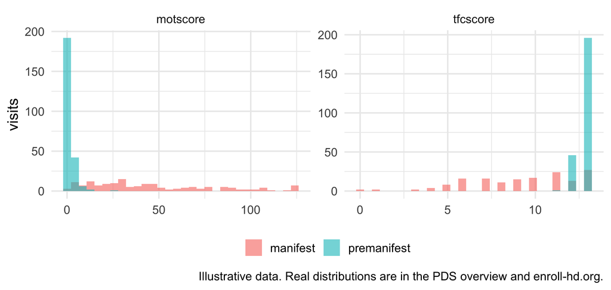

- Total motor score piles up at **0** (about a quarter of baseline HDGEC visits in the lowest CAP quartile) and is right-skewed to 124.
- TFC, FAS and the Independence Scale pile up at their **maximum** for early participants.
- Consequence: means and t-tests mislead. Consider transformations, zero-inflated or negative-binomial models for TMS, ordinal or beta-type models for TFC, or model change rather than level.

## Behaviour behaves differently

- PBA-s domains (depression, irritability, psychosis, apathy, executive) track disease stage **weakly**; apathy is the exception and rises with progression.
- Behavioural items are informant-dependent: the “worst” ratings are blank at the Enroll-HD baseline, and several items are 9 (not assessable) when the participant came alone.
- Suicidal ideation on PBA-s should agree with the C-SSRS rows and the event file. Check it.

## Selection and follow-up

- Cohort skews toward higher socioeconomic status and better health; ethnic diversity is limited (about 92% Caucasian).
- Retention: about **80%** of premanifest and **55%** of manifest carriers remain at 7 years (withdrawal, death, loss to follow-up).
- Visits are annual in intent: median gap **374 days**, but skewed, with gaps up to 6.8 years. People skip years and return, or pause during clinical trials.

```r
pds$enroll |>
  group_by(subjid) |>
  arrange(seq, .by_group = TRUE) |>
  mutate(gap_days = visdy - lag(visdy)) |>
  ungroup() |>
  summarise(n_gaps = sum(!is.na(gap_days)),
            median_gap = median(gap_days, na.rm = TRUE),
            longest_gap = max(gap_days, na.rm = TRUE))
```

```
# A tibble: 1 × 3
  n_gaps median_gap longest_gap
   <int>      <int>       <int>
1      9        367         437
```

# 8. Age, CAG and time in models

## Cross-sectional: index progression with CAP

At study entry, disease burden differs by age **and** CAG. Enter both, or their product.

```r
baseline_carriers <- pds$enroll |>
  filter(visit == "Baseline") |>
  inner_join(pds$profile |> mutate(cag = parse_number(caghigh)) |>
               filter(cag >= 40), by = "subjid") |>
  mutate(age = parse_number(age), cap = cap_score(age, cag))

fit_cap <- lm(sdmt1 ~ cap + sex + education_years, data = baseline_carriers)
broom::tidy(fit_cap, conf.int = TRUE)
```

- Education matters for cognitive outcomes; sex interactions matter in some contexts.
- CAP groups (below 88, 88 to 119, above 119) are a defensible early/mid/late split for CAG 40+.
- Beware confounding by CAG: in Enroll-HD, participants with a history of drug use have milder motor signs **only because they have shorter CAG expansions**.

## Longitudinal: use time since entry, not age, as the clock

```r
library(lme4)

carrier_visits <- visits |>
  filter(cag >= 40) |>
  mutate(cap_group = cut(cap_score(parse_number(age_0), cag),
                         breaks = c(-Inf, 88, 119, Inf),
                         labels = c("early", "mid", "late")))

fit_slopes <- lmer(
  motscore ~ years_in_study * cap_group + sex + (1 + years_in_study | subjid),
  data = carrier_visits
)
broom.mixed::tidy(fit_slopes, effects = "fixed", conf.int = TRUE)
```

- Time 0 = the baseline visit; CAP (or CAP group) carries progression **up to** entry. Within a CAP group, change over a few years is close to linear.
- Over the whole adult lifespan trajectories are not linear; if age is the clock use splines or fractional polynomials.
- Random slopes are the norm: people progress at different rates.

## Time to a landmark: survival methods

```r
library(survival)

onset_data <- motor_onset |>
  filter(!dcl4_at_entry) |>
  inner_join(pds$profile |> mutate(cag = parse_number(caghigh)), by = "subjid") |>
  inner_join(pds$participation |> select(subjid, age_0), by = "subjid") |>
  mutate(
    time_years = coalesce(onset_visdy, last_visdy) / 365.25,
    event      = as.integer(converted),
    cap_entry  = cap_score(parse_number(age_0), cag)
  )

fit_cox <- coxph(Surv(time_years, event) ~ cap_entry + sex, data = onset_data)
broom::tidy(fit_cox, exponentiate = TRUE, conf.int = TRUE)
```

- Exclude people who were already past the landmark at entry, and think about whether that exclusion biases you.
- Joint longitudinal-survival models exist for using all visits; see Long and Mills (2018).

## Signal, noise and clinical trials

Enroll-HD is used to design trials. The quantity that matters is the outcome’s **signal-to-noise ratio**: mean annual change divided by the within-person SD of annual change.

# 9. Coded therapies and comorbidities

## Codes in the current PDS

| What | Column | Format |
| --- | --- | --- |
| Drug | `cmtrt__decod` | RX + 9 digits (internal); `cmtrt__modify` is the English term |
| Active ingredients | `cmtrt__ing` | comma-separated |
| ATC classes | `cmtrt__atc` | comma-separated ATC codes |
| Indication | `cmindc__decod` | CX + 9 digits; `cmindc__modify` English |
| Comorbidity | `mhterm__decod` | ICD-10 (2014) |
| Procedure | `mhterm__decod` | CX + 9 digits |
| Ongoing | `cmenrf`, `mhenrf` | 1 if and only if the stop day is blank |

Older releases used WHO Drug Dictionary and MedDRA codes; the format changed, the logic did not.

## Filter by therapeutic class, not by name

```r
on_antidepressant <- pds$pharmacotx |>
  mutate(atc_codes = str_split(cmtrt__atc, ",\\s*")) |>
  filter(map_lgl(atc_codes, ~ any(str_starts(.x, "N06A")))) |>
  mutate(ongoing = cmenrf == 1,
         duration_days = cmendy - cmstdy) |>
  select(subjid, cmtrt__modify, cmtrt__atc, cmstdy, cmendy, ongoing, duration_days)
on_antidepressant
```

```
# A tibble: 3 × 7
  subjid     cmtrt__modify cmtrt__atc cmstdy cmendy ongoing duration_days
  <chr>      <chr>         <chr>       <dbl>  <dbl> <lgl>           <dbl>
1 R000000001 Sertraline    N06AB06      -120    380 FALSE             500
2 R000000002 Citalopram    N06AB04       -15    -15 FALSE               0
3 R000000002 Citalopram    N06AB04       -15    -15 FALSE               0
```

Note `R000000002`: an exact duplicate row and a zero-day duration from partial-date imputation. Both are real-data features.

## Comorbidities and ICD-10 chapters

```r
depression_history <- pds$comorbid |>
  filter(str_starts(mhterm__decod, "F32|F33")) |>
  distinct(subjid) |>
  mutate(depression_ever = TRUE)

pds$profile |>
  left_join(depression_history, by = "subjid") |>
  mutate(depression_ever = coalesce(depression_ever, FALSE)) |>
  count(depression_ever)
```

- ICD-10 is hierarchical: `str_starts` on the chapter or block prefix gives you the family of codes.
- `mhbodsys` gives a coarse body-system code (1 to 17) when you just need organ systems.
- Comorbidity and therapy rows are participant-level, not visit-level: align them to visits with `cmstdy`/`cmendy` and `visdy`.

# 10. Data quality and a pre-analysis checklist

## Quality you get, and quality you must add

**Provided**: EDC edit checks and auto-computed totals, remote and on-site monitoring, central statistical monitoring, central coding, a published list of unusual but verified findings.

**Yours to do**:

- Recode 9996 to 9999 to `NA` before any arithmetic.
- Parse aggregated text columns explicitly and keep the censoring flag.
- Recompute totals from items where items are available and compare.
- Confirm one baseline per participant at `visdy` 0 and `seq` 1, increasing `visdy`, and that `visitnum` equals the number of visit rows.
- Look for known oddities before calling them bugs: pack-years of 2005, parental onset age 0, zero-length prescriptions.
- Decide and document how to treat duplicates, unscheduled visits and phone contacts.

## A tidy project for Enroll-HD analyses

```
my-enrollhd-analysis/
  my-enrollhd-analysis.Rproj
  renv.lock                 # frozen package versions
  data/                     # the PDS extract, git-ignored, never copied around
  R/
    read_pds.R              # one function per concern
    recode_missing.R
    derive_scores.R
    build_analysis_set.R
  analysis/
    01_cohort.qmd           # one Quarto document per analysis question
    02_progression.qmd
  output/                   # figures and tables, regenerated, git-ignored
  SAP.md                    # the statistical analysis plan, written first
```

- Functions take a tibble and return a tibble. Pipelines read top to bottom. Names say what, comments say why.
- The analysis set is built by code from the raw PDS every time; no hand edits.

## Before you begin (from the Enroll-HD statisticians)

1. Write the research question and objectives down, then search the literature.
2. Define the population of interest and how it is operationalised in PDS variables.
3. Check feasibility: are there enough of those people, with enough visits?
4. Write a statistical analysis plan: dataset and release, measures, cleaning and outlier rules, missing-data strategy, methods, covariates and modifiers (CAG × age, sex, education), multiplicity, reproducibility. Consider pre-registering it.
5. Work with a statistician throughout, not only at the end.
6. Cite the release version and the documentation you relied on.

# 11. HDClarity, and simulated releases for testing your code

## What HDClarity is

- A longitudinal **CSF and blood collection study nested in Enroll-HD** (UCL sponsor, CHDI collaborator, NCT02855476), open since January 2017, aiming at about 2,500 participants.
- Every HDClarity participant is an Enroll-HD participant with the **same `subjid`**; demographics, CAG, logs and the clinical scales come from the Enroll-HD visit.
- PDS4 (data cut January 2026): **999 participants, 1,443 visit packages**, 38 sites in 9 countries; regions Europe, North America, Australasia.
- Ages 18 to 75 (21 to 75 for manifest HD); the six recruited cohorts are balanced as far as possible, so the mix differs from Enroll-HD.

`hdcat` (HDClarity coding, protocol v4)

| code | cohort | rule |
| --- | --- | --- |
| 1 | early premanifest | DCL < 4, CAG >= 40, DBS < 250 |
| 2 | late premanifest | DCL < 4, CAG >= 40, DBS >= 250 |
| 3 | early HD | DCL 4, TFC 7 to 13 |
| 4 | moderate HD | DCL 4, TFC 3 to 6 |
| 5 | advanced HD | DCL 4, TFC 0 to 2 |
| 6 | healthy control | CAG < 36 |
| 8 | incomplete penetrance | CAG 36 to 39 |

DBS = (CAG − 35.5) × age; `dbs` is in the visits file.

## A visit package (one `cycle`)

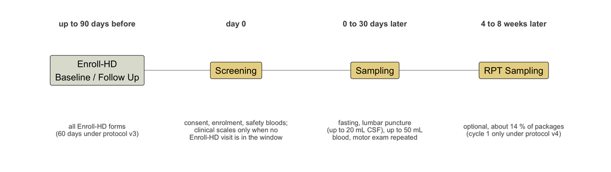

- Packages recur **annually** (plus or minus two months) as cycles 2, 3, 4; three missed samplings end participation.
- A package is released **only if at least one CSF sample was collected** (about 98 % of punctures succeed). A dropped package leaves a **gap in `cycle`**.
- Adverse events, phone contacts, end forms, kit ids and numeric lab results are not in the PDS (SRC or IDS tier).

## Nine files, one new grain

| File | Grain | Key | Content |
| --- | --- | --- | --- |
| profile | participant | subjid | Enroll-HD demographics, HDCC, CAG, plus fhx, hdcsf, proteomic |
| participation | participant x cycle | subjid + cycle | age and hdcat at screening, status, day anchors, visit1..21, vis1dy..21, vis1smpl..21 |
| visits | visit | subjid + cycle + studyid + visit | every clinical form (Enroll-HD rows), motor at sampling, dbs, hdcat, CAP, HD-ISS, lab flags, csfpdy, csfpage, plsmsage |
| assessment | visit | subjid + cycle + seq | 1/blank per form present: enrollment, eligibility, safety labs, csf, csfquality, clinical forms |
| csfquality | sampling visit x row | subjid + cycle + visit + row | triplicate erythrocyte and leukocyte counts per uL with their flags |
| pharmacotx, nutsuppl, nonpharmacotx, comorbid | participant, repeating | subjid + row | the Enroll-HD log forms, same columns as the Enroll-HD PDS |

Compared with the Enroll-HD PDS: no `enroll`, `registry`, `adhoc` or `event`; one `visits` file for both studies; `cycle` everywhere.

## Keys and days differ from the Enroll-HD PDS

- `visdy` counts days since the participant’s **first HDClarity screening**, so the Enroll-HD row of cycle 1 is negative. It **cannot be aligned** with the Enroll-HD PDS `visdy`; the offset is an SRC-request variable.
- `seq` numbers every visit of a participant chronologically **across cycles**; `visit` is Baseline or Follow Up (`studyid` ENR) and Screening, Sampling or RPT Sampling (`studyid` CLR).
- `hdcat` is decided at screenings 1 and 5 and **carried forward** in between, so a premanifest participant can show DCL 4 at a later sampling (19 participants in PDS4). Rule checks must use the screening where it was set.
- Safety bloods arrive as categorical flags (`wbcres1c` high/low, `lbres1` passed/failed, a second sample in the `2` columns); the numbers are not released.

```r
clr$visits |>
  filter(subjid == "R000000004") |>
  select(cycle, seq, studyid, visit, visdy, hdcat, dbs, motscore, diagconf, csfpdy)
```

```
# A tibble: 6 × 10
  cycle   seq studyid visit     visdy hdcat   dbs motscore diagconf csfpdy
  <dbl> <dbl> <chr>   <chr>     <dbl> <dbl> <dbl>    <dbl>    <dbl>  <dbl>
1     1     1 ENR     Follow Up   -20    NA   NA         6        2     NA
2     1     2 CLR     Screening     0     1  140.       NA       NA     NA
3     1     3 CLR     Sampling     21     1  140.        8        3     21
4     2     4 ENR     Follow Up   340    NA   NA        15        4     NA
5     2     5 CLR     Screening   371     1  144        NA       NA     NA
6     2     6 CLR     Sampling    380     1  144        16        4    380
```

## Reading a package in R

The participation arrays gain a samples column (`vis1smpl ...`). The suffix, not the stem, tells the three arrays apart, so capture it and pivot twice: long over every array cell, then wide by array.

```r
arrays <- clr$participation |>
  pivot_longer(matches("^(visit|vis)\\d+"),
               names_to = c("stem", "index", "suffix"),
               names_pattern = "^(visit|vis)(\\d+)(dy|smpl)?$",
               values_transform = as.character) |>
  mutate(array = case_when(suffix == "smpl" ~ "samples", suffix == "dy" ~ "day", TRUE ~ "type")) |>
  select(subjid, cycle, index, array, value) |>
  pivot_wider(names_from = array, values_from = value) |>
  filter(!is.na(type)) |>
  mutate(index = as.integer(index), day = as.integer(day))
arrays |> filter(subjid == "R000000001")
```

```
# A tibble: 6 × 6
  subjid     cycle index type      day samples
  <chr>      <dbl> <int> <chr>   <int> <chr>
1 R000000001     1     1 ENR/FUP   -41 <NA>
2 R000000001     1     2 SCR         0 <NA>
3 R000000001     1     3 BS         14 Plasma, Serum
4 R000000001     1     4 BS2        49 CSF, Plasma, Serum
5 R000000001     3     1 SCR       735 <NA>
6 R000000001     3     2 BS        752 CSF, Plasma, Serum
```

`type` uses the participation codes ENR/BL, ENR/FUP, SCR, BS and BS2; `samples` reads “CSF, Plasma, Serum” or, after a failed puncture, “Plasma, Serum”.

## CSF quality and the category rules as tests

```r
clr$visits |>
  filter(!is.na(csfpdy)) |>
  left_join(clr$csfquality, by = c("subjid", "cycle", "studyid", "visit", "visdy")) |>
  transmute(subjid, cycle, visit, visdy, ery = (erycnt1 + erycnt2 + erycnt3) / 3, eryflag, leukflag)
```

```
# A tibble: 5 × 7
  subjid     cycle visit        visdy      ery eryflag leukflag
  <chr>      <dbl> <chr>        <dbl>    <dbl>   <dbl>    <dbl>
1 R000000001     1 RPT Sampling    49    4           0        0
2 R000000001     3 Sampling       752 1450           1        0
3 R000000003     1 Sampling         7    0.333       0        0
4 R000000004     1 Sampling        21   11.7         0        1
5 R000000004     2 Sampling       380    1.67        0        0
```

```r
clr_checks <- clr$visits |>
  filter(visit == "Screening", cycle %in% c(1, 5)) |>
  left_join(clr$profile |> transmute(subjid, cag = parse_number(caghigh)), by = "subjid") |>
  summarise(
    controls_below_36 = all(cag < 36 | hdcat != 6),
    ip_36_to_39       = all(between(cag, 36, 39) | hdcat != 8),
    dbs_formula       = all(is.na(dbs) | abs(dbs - (cag - 35.5) * age) <= (cag - 35.5)),   # age is in whole years
    premanifest_dbs   = all(!hdcat %in% c(1, 2) | (hdcat == 1) == (dbs < 250))
  )
clr_checks
```

```
# A tibble: 1 × 4
  controls_below_36 ip_36_to_39 dbs_formula premanifest_dbs
  <lgl>             <lgl>       <lgl>       <lgl>
1 TRUE              TRUE        TRUE        TRUE
```

## Simulated releases for testing your code before the data arrive

Two tidyverse simulators live in the project this deck belongs to. Both are built **only from public documentation** and write synthetic files that say so in every folder.

|  | Enroll-HD PDS7 | HDClarity PDS4 |
| --- | --- | --- |
| script | `Rscript run_simulation.R 30511` | `Rscript hdclarity/run_hdclarity.R` |
| output | 11 files, 30,511 participants, 9 minutes | 9 files, 999 participants, 30 seconds |
| nested | one latent disease clock per participant | drawn from a simulated Enroll-HD population, so scores agree across both |
| calibrated to | PDS7 overview, statistical report, *Analyzing Data* figures | PDS4 and PDS3 overviews, structure guide, protocol, lab manual |
| checks | 88 of 90 pass (CAP quartile and TMS median are known misses) | 73 of 73 pass |

- Each release carries the dictionary column set and order, a `codebook.csv`, an `anomaly_log.csv` of the deliberate oddities, a `validation_report.md` and the disclaimer.
- They reproduce the conventions from sections 3 to 5 and 9: recoded ids, day offsets, aggregated text, 9996 to 9999 codes, duplicate log rows, partial-date artefacts, the missing `cycle` and the carried `hdcat`.

```r
sim <- readRDS(here::here("hdclarity", "output", "hdclarity_sim_999_20260923_20260923", "hdclarity_sim.rds"))
sim$visits |> count(studyid, visit)
```

## What the simulators are for, and what they are not

**Use them to**

- write and test `read_pds()`, joins, reshapes and derived scores before the extract arrives;
- rehearse the rule checks of sections 6 and 11 so they run on day one;
- size a pipeline: file sizes, run time, memory;
- teach, as this deck does, without touching participant data.

**Do not use them to**

- estimate anything about Huntington’s disease: margins are matched, joint structure is one latent clock plus noise;
- judge site or country effects (sites are not in the PDS, none are simulated);
- study laboratory values (flags are independent draws; CSF cell-count shapes are assumed);
- explore the SRC or IDS tiers, adverse events or proteomics (not generated).

Every number in a simulated release is synthetic. Cite the real release and its documentation, never the simulator, in any result.

## Where to go next

- Analyzing Data hub: https://www.enroll-hd.org/for-researchers/analyzing-data/
  - Special characteristics of HD data; Age and CAG length in HD data analysis; Data handling and management tips; Benefits and challenges of observational data; Using observational data to inform clinical trial design; Enrichment in clinical trial recruitment; Before you begin.
- Documentation hub (dictionary, protocol, CRFs, coding, overview): https://www.enroll-hd.org/for-researchers/data-support-documentation/
- HDClarity: https://www.hdclarity.net/; its protocol, lab manual, PDS4 dictionary, dataset-structure guide and overview are on the same Enroll-HD documentation hub.
- Tools: PDS Data Explorer, HD-ISS calculator, Atlas of HD phenotype (same site).
- Key papers: Landwehrmeyer et al. 2017 (Enroll-HD design); Warner et al. 2020 (CAP); Long & Mills 2018 (joint models); Schobel et al. 2017 (cUHDRS); Langbehn et al. 2010 (CAG and onset); Tabrizi et al. 2013 (TRACK-HD).

Questions, corrections and additions are welcome. Source, toy data and rendering instructions: https://github.com/stat-absk/enrollhd-getting-started.